# **Case QuantumFinance - Disciplina NLP - Classificador de chamados**

#### Comparação entre stemização e lematização

```python
from nltk import RSLPStemmer

stemmer = RSLPStemmer()

def stem_text(text):
    """Aplica stemização RSLP"""
    tokens = clean_text(text).split()
    stemmed = [stemmer.stem(word) for word in tokens if word not in stop_words_pt and len(word) > 2]
    return ' '.join(stemmed)

# Exemplo comparativo
texto_teste = "Os clientes solicitaram o desbloqueio dos cartões de crédito que foram bloqueados."
print("=== Comparação Stemização vs Lematização ===")
print(f"\nTexto original:\n{texto_teste}")
print(f"\nCom Stemização (RSLP):\n{stem_text(texto_teste)}")
print(f"\nCom Lematização (spaCy):\n{preprocess_text(texto_teste)}")

print("\n✓ Decisão: A lematização preserva melhor o sentido das palavras, sendo mais adequada para este domínio.")
print("  Stemização pode ser útil para reduzir ainda mais o vocabulário, mas pode perder nuances importantes.")
```

```
=== Comparação Stemização vs Lematização ===

Texto original:
Os clientes solicitaram o desbloqueio dos cartões de crédito que foram bloqueados.

Com Stemização (RSLP):
client solicit desbloquei cart crédit bloqueados.

Com Lematização (spaCy):
cliente solicitarar desbloqueio cartão crédito bloquear

✓ Decisão: A lematização preserva melhor o sentido das palavras, sendo mais adequada para este domínio.
  Stemização pode ser útil para reduzir ainda mais o vocabulário, mas pode perder nuances importantes.
```

```python
# IMPLEMENTAÇÃO: Lematização otimizada para performance
import spacy

# 1) Carregar spaCy otimizado
try:
    nlp = spacy.load("pt_core_news_sm", disable=["parser", "ner"])  # só POS + lemmatização
    nlp.max_length = 2_000_000  # folga para textos maiores
    print("✓ Modelo spaCy otimizado carregado!")
except:
    print("⚠ Modelo spaCy não encontrado. Execute: python -m spacy download pt_core_news_sm")
    nlp = None

# 2) Lematização em lote otimizada
def lemmatize_text_batch(texts, keep_pos=("NOUN", "VERB", "ADJ"), batch_size=300, n_process=-1):
    """
    Lematização otimizada para grandes volumes de texto
    """
    if nlp is None:
        return texts

    sw = stop_words_pt if isinstance(stop_words_pt, set) else set(stop_words_pt)
    single = isinstance(texts, str)
    if single:
        texts = [texts]

    out = []
    with nlp.select_pipes(disable=[]):  # já desativamos parser/ner no load
        for doc in nlp.pipe(texts, batch_size=batch_size, n_process=n_process):
            lemmas = [
                t.lemma_ for t in doc
                if t.pos_ in keep_pos and len(t.lemma_) > 2 and t.lemma_ not in sw
            ]
            out.append(" ".join(lemmas))

    return out[0] if single else out

# 3) Pré-processador vetorizado
def preprocess_text_series(texts, use_lemmatization=True):
    """
    Pré-processamento otimizado para Series do pandas
    """
    texts = texts.fillna("").astype(str)
    texts = texts.map(clean_text)

    if not use_lemmatization:
        sw = stop_words_pt if isinstance(stop_words_pt, set) else set(stop_words_pt)
        return texts.map(lambda t: " ".join(w for w in t.split() if len(w) > 2 and w not in sw))

    return pd.Series(lemmatize_text_batch(texts, batch_size=300, n_process=-1), index=texts.index)
```

```
✓ Modelo spaCy otimizado carregado!
```

```python
# APLICAÇÃO: Pré-processamento otimizado
print("=== APLICAÇÃO: Pré-processamento Otimizado ===")
print("Aplicando lematização otimizada...")

# Aplicar pré-processamento otimizado
df['descricao_processada'] = preprocess_text_series(df['descricao_limpa'], use_lemmatization=True)

# Comparar
print("\nExemplo:")
exemplo_idx = 0
print(f"ORIGINAL: {df['descricao_reclamacao'].iloc[exemplo_idx][:150]}...")
print(f"\nPROCESSADO: {df['descricao_processada'].iloc[exemplo_idx][:150]}...")

print("\n✓ Pré-processamento otimizado concluído!")
print("✓ Justificativa: Otimizações de performance (batch processing, paralelização) reduzem tempo de execução")
```

```
=== APLICAÇÃO: Pré-processamento Otimizado ===
Aplicando lematização otimizada...

Exemplo:
ORIGINAL: Bom dia, meu nome é xxxx xxxx e agradeço se você puder me ajudar a acabar com os serviços de membro do cartão bancário.
Em 2018, escrevi para Chase s...

PROCESSADO: bom dia nome agradeço puder ajudar acabar serviço membro cartão bancário escrevi chase solicitar verificação dívida enviar declaração aceitável pedir ...

✓ Pré-processamento otimizado concluído!
✓ Justificativa: Otimizações de performance (batch processing, paralelização) reduzem tempo de execução
```

```python
df.head()
```

|  | id_reclamacao | data_abertura | categoria | descricao_reclamacao | num_caracteres | num_palavras | descricao_limpa | descricao_processada |
| --- | --- | --- | --- | --- | --- | --- | --- | --- |
| 0 | 3229299 | 2019-05-01T12:00:00-05:00 | Hipotecas / Empréstimos | Bom dia, meu nome é xxxx xxxx e agradeço se vo... | 505 | 88 | bom dia, meu nome é e agradeço se você puder m... | bom dia nome agradeço puder ajudar acabar serv... |
| 1 | 3199379 | 2019-04-02T12:00:00-05:00 | Cartão de crédito / Cartão pré-pago | Atualizei meu cartão xxxx xxxx em xx/xx/2018 e... | 350 | 58 | atualizei meu cartão em // e fui informado pel... | atualizei cartão informar agente fazer atualiz... |
| 2 | 3233499 | 2019-05-06T12:00:00-05:00 | Cartão de crédito / Cartão pré-pago | O cartão Chase foi relatado em xx/xx/2019. No ... | 228 | 33 | o cartão chase foi relatado em //. no entanto,... | cartão relatar //. entanto pedido fraudulento ... |
| 3 | 3180294 | 2019-03-14T12:00:00-05:00 | Cartão de crédito / Cartão pré-pago | Em xx/xx/2018, enquanto tentava reservar um ti... | 1577 | 276 | em //, enquanto tentava reservar um ticket , m... | tentar reservar ticket deparar oferta aplicar ... |
| 4 | 3224980 | 2019-04-27T12:00:00-05:00 | Serviços de conta bancária | Meu neto me dê cheque por {$ 1600,00} Eu depos... | 607 | 108 | meu neto me dê cheque por {$ ,} eu depositei -... | neto cheque depositei conta chase fundo limpar... |

### Separação Treino/Teste (75%/25%)

**random_state=42** e split **estratificado** para manter a proporção das classes.

```python
# Separação estratificada dos dados
from sklearn.model_selection import train_test_split


X = df['descricao_reclamacao']
y = df['categoria']

X_train, X_test, y_train, y_test = train_test_split(
    X, y,
    test_size=0.25,
    random_state=42,
    stratify=y
)

print(f"Conjunto de Treino: {len(X_train)} amostras ({len(X_train)/len(X)*100:.1f}%)")
print(f"Conjunto de Teste: {len(X_test)} amostras ({len(X_test)/len(X)*100:.1f}%)")
print(f"\nDistribuição de classes no treino:")
print(y_train.value_counts())
```

```
Conjunto de Treino: 15804 amostras (75.0%)
Conjunto de Teste: 5268 amostras (25.0%)

Distribuição de classes no treino:
categoria
Serviços de conta bancária             3871
Cartão de crédito / Cartão pré-pago    3754
Roubo / Relatório de disputa           3616
Hipotecas / Empréstimos                2888
Outros                                 1675
Name: count, dtype: int64
```

## Experimento 1 TF_IDF + Regressão Logística

**Justificativa da Vetorização:**

- **TF-IDF (1-2 gram)**: captura termos curtos e combina frequência local (TF) com importância global (IDF)
- **ngram_range=(1,2)**: unigramas + bigramas capturam expressões do domínio
- **sublinear_tf**: aplica log(TF) para suavizar impacto de termos muito frequentes
- **min_df**: filtra termos que aparecem em poucos documentos (ruído)

```python
import time
from sklearn.feature_extraction.text import TfidfVectorizer
from sklearn.linear_model import LogisticRegression
from sklearn.metrics import accuracy_score, f1_score
from sklearn.model_selection import GridSearchCV, StratifiedKFold
from sklearn.pipeline import Pipeline


print("="*80)
print("EXPERIMENTO 1: TF-IDF + REGRESSÃO LOGÍSTICA")
print("="*80)

# Pré-processar os textos (aplicar lematização)
print("\n[1/5] Pré-processando textos...")
X_train_processed = preprocess_text_series(X_train, use_lemmatization=True)
X_test_processed = preprocess_text_series(X_test, use_lemmatization=True)
print(f"✓ Processados {len(X_train_processed)} textos de treino e {len(X_test_processed)} de teste")

# Definir o pipeline
print("\n[2/5] Configurando pipeline e Grid Search...")
pipeline_lr = Pipeline([
    ('tfidf', TfidfVectorizer()),
    ('clf', LogisticRegression(max_iter=1000, random_state=42))
])

# Grid de hiperparâmetros
param_grid_lr = {
    'tfidf__ngram_range': [(1, 1), (1, 2)],
    'tfidf__sublinear_tf': [True, False],
    'tfidf__min_df': [1, 2, 3],
    'clf__C': [0.5, 1, 2, 4]
}

# GridSearchCV com 5-fold estratificado
cv = StratifiedKFold(n_splits=5, shuffle=True, random_state=42)

grid_search_lr = GridSearchCV(
    pipeline_lr,
    param_grid_lr,
    cv=cv,
    scoring='f1_weighted',
    n_jobs=-1,
    verbose=1
)

# Treinamento
print("\n[3/5] Treinando modelo com GridSearchCV (5-fold)...")
start_time = time.time()
grid_search_lr.fit(X_train_processed, y_train)
train_time = time.time() - start_time

print(f"✓ Treinamento concluído em {train_time:.2f} segundos")

# Melhores hiperparâmetros
print("\n[4/5] Melhores hiperparâmetros encontrados:")
for param, value in grid_search_lr.best_params_.items():
    print(f"  - {param}: {value}")

# Avaliação no conjunto de teste
print("\n[5/5] Avaliação no conjunto de teste...")
y_pred_lr = grid_search_lr.predict(X_test_processed)
f1_test_lr = f1_score(y_test, y_pred_lr, average='weighted')
accuracy_test_lr = accuracy_score(y_test, y_pred_lr)

print(f"\nResultados no Teste:")
print(f"  - F1-Score (weighted): {f1_test_lr:.4f}")
print(f"  - Accuracy: {accuracy_test_lr:.4f}")
print(f"  - Tempo de treinamento: {train_time:.2f}s")

# Armazenar resultados
results_exp1 = {
    'model': 'TF-IDF + Regressão Logística',
    'best_params': grid_search_lr.best_params_,
    'f1_cv': grid_search_lr.best_score_,
    'f1_test': f1_test_lr,
    'accuracy_test': accuracy_test_lr,
    'train_time': train_time,
    'grid_search': grid_search_lr
}
```

```
================================================================================
EXPERIMENTO 1: TF-IDF + REGRESSÃO LOGÍSTICA
================================================================================

[1/5] Pré-processando textos...
✓ Processados 15804 textos de treino e 5268 de teste

[2/5] Configurando pipeline e Grid Search...

[3/5] Treinando modelo com GridSearchCV (5-fold)...
Fitting 5 folds for each of 48 candidates, totalling 240 fits
✓ Treinamento concluído em 994.20 segundos

[4/5] Melhores hiperparâmetros encontrados:
  - clf__C: 1
  - tfidf__min_df: 3
  - tfidf__ngram_range: (1, 1)
  - tfidf__sublinear_tf: False

[5/5] Avaliação no conjunto de teste...

Resultados no Teste:
  - F1-Score (weighted): 0.9132
  - Accuracy: 0.9134
  - Tempo de treinamento: 994.20s
```

```
================================================================================
RELATÓRIO DE CLASSIFICAÇÃO - EXPERIMENTO 1
================================================================================
                                     precision    recall  f1-score   support

Cartão de crédito / Cartão pré-pago       0.92      0.93      0.92      1252
            Hipotecas / Empréstimos       0.92      0.93      0.92       962
                             Outros       0.91      0.84      0.87       558
       Roubo / Relatório de disputa       0.90      0.89      0.90      1206
         Serviços de conta bancária       0.92      0.94      0.93      1290

                           accuracy                           0.91      5268
                          macro avg       0.91      0.90      0.91      5268
                       weighted avg       0.91      0.91      0.91      5268
```

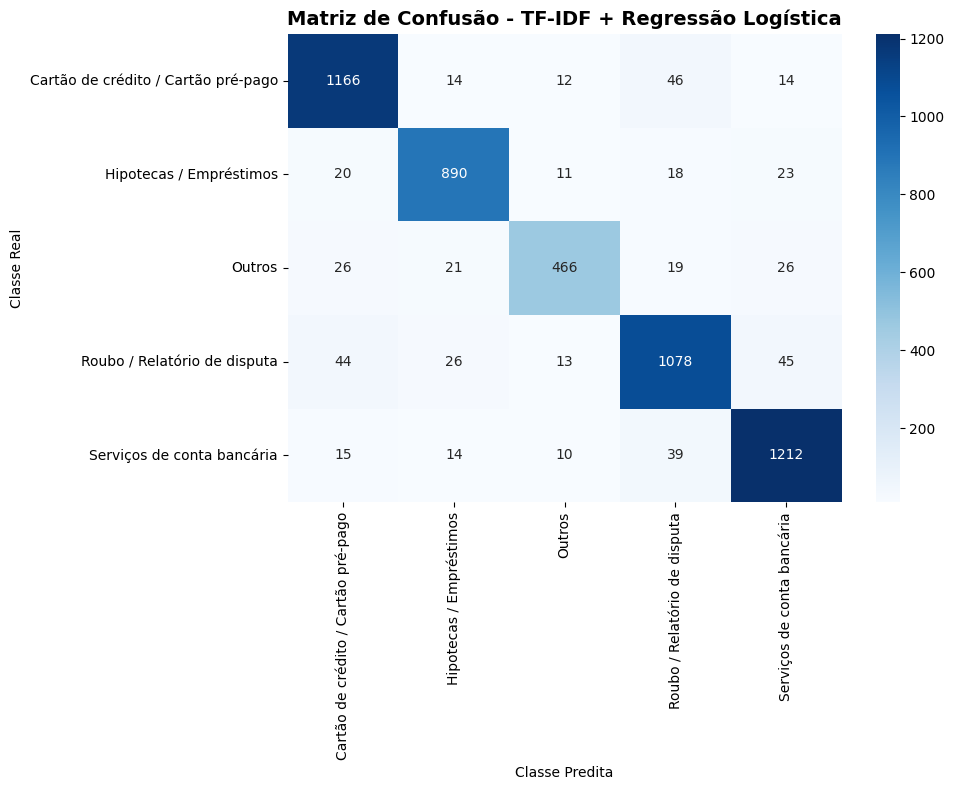

```python
# Relatório de classificação detalhado
from sklearn.metrics import classification_report, confusion_matrix


print("\n" + "="*80)
print("RELATÓRIO DE CLASSIFICAÇÃO - EXPERIMENTO 1")
print("="*80)
print(classification_report(y_test, y_pred_lr))

# Matriz de confusão
fig, ax = plt.subplots(figsize=(10, 8))
cm = confusion_matrix(y_test, y_pred_lr)
sns.heatmap(cm, annot=True, fmt='d', cmap='Blues',
            xticklabels=grid_search_lr.classes_,
            yticklabels=grid_search_lr.classes_,
            ax=ax)
ax.set_title('Matriz de Confusão - TF-IDF + Regressão Logística', fontsize=14, fontweight='bold')
ax.set_ylabel('Classe Real')
ax.set_xlabel('Classe Predita')
plt.tight_layout()
plt.show()
```

```python
# Análise das features mais importantes por classe
print("\n=== Features mais importantes por classe (Top 10) ===\n")

# Obter o vetorizador e o classificador do melhor modelo
best_model_lr = grid_search_lr.best_estimator_
vectorizer = best_model_lr.named_steps['tfidf']
classifier = best_model_lr.named_steps['clf']

# Obter nomes das features
feature_names = vectorizer.get_feature_names_out()

# Para cada classe, mostrar as features com maiores coeficientes
for idx, classe in enumerate(classifier.classes_):
    coefs = classifier.coef_[idx]
    top_indices = np.argsort(coefs)[-10:][::-1]
    top_features = [feature_names[i] for i in top_indices]
    top_coefs = [coefs[i] for i in top_indices]

    print(f"{classe}:")
    for feature, coef in zip(top_features, top_coefs):
        print(f"  {feature}: {coef:.4f}")
    print()
```

```
=== Features mais importantes por classe (Top 10) ===

Cartão de crédito / Cartão pré-pago:
  crédito: 15.1312
  cartão: 10.0057
  relatório: 6.2061
  consulta: 3.1445
  creditar: 2.6633
  relatar: 2.4023
  dívida: 2.0722
  pergunta: 2.0087
  pontuação: 1.9000
  card: 1.8423

Hipotecas / Empréstimos:
  empréstimo: 11.8292
  hipoteca: 8.4260
  casa: 5.3087
  propriedade: 3.5610
  modificação: 3.3259
  hipotecário: 3.2565
  documento: 2.9606
  dívida: 2.2686
  venda: 2.2607
  imposto: 2.1899

Outros:
  pagamento: 18.9880
  saldo: 2.7261
  mês: 2.1084
  atrasar: 2.0981
  declaração: 2.0266
  mensal: 1.6217
  atraso: 1.5856
  auto: 1.4842
  arrendamento: 1.3446
  aplicar: 1.2858

Roubo / Relatório de disputa:
  cobrança: 9.5050
  acusação: 8.6600
  cobrar: 6.4378
  disputa: 5.6825
  transação: 5.1083
  taxa: 4.8447
  carga: 4.5684
  comerciante: 4.1184
  compra: 3.6223
  reivindicação: 3.4459

Serviços de conta bancária:
  conta: 11.6094
  cheque: 6.2210
  banco: 5.0655
  dinheiro: 4.6819
  bank: 4.3031
  fundo: 3.8841
  depósito: 3.7985
  filial: 3.2130
  verificação: 2.9315
  bancário: 2.3608
```

### **Experimento 2: TF-IDF + Linear SVM**

**Justificativa do Modelo:**

- **LinearSVC** é especialmente eficiente com dados de alta dimensionalidade (vetores TF-IDF)
- Busca maximizar a margem entre classes, sendo robusto para textos esparsos
- Compararemos com Regressão Logística para identificar qual captura melhor os padrões

```python
from sklearn.svm import LinearSVC


print("="*80)
print("EXPERIMENTO 2: TF-IDF + LINEAR SVM")
print("="*80)

# Pipeline (textos já foram pré-processados no Exp. 1)
print("\n[1/4] Configurando pipeline e Grid Search...")
pipeline_svm = Pipeline([
    ('tfidf', TfidfVectorizer()),
    ('clf', LinearSVC(max_iter=2000, random_state=42))
])

# Grid de hiperparâmetros
param_grid_svm = {
    'tfidf__ngram_range': [(1, 1), (1, 2)],
    'tfidf__sublinear_tf': [True, False],
    'tfidf__min_df': [1, 2, 3],
    'clf__C': [0.5, 1, 2, 4],
    'clf__loss': ['hinge', 'squared_hinge']
}

# GridSearchCV
grid_search_svm = GridSearchCV(
    pipeline_svm,
    param_grid_svm,
    cv=cv,
    scoring='f1_weighted',
    n_jobs=-1,
    verbose=1
)

# Treinamento
print("\n[2/4] Treinando modelo com GridSearchCV (5-fold)...")
start_time = time.time()
grid_search_svm.fit(X_train_processed, y_train)
train_time_svm = time.time() - start_time

print(f"✓ Treinamento concluído em {train_time_svm:.2f} segundos")

# Melhores hiperparâmetros
print("\n[3/4] Melhores hiperparâmetros encontrados:")
for param, value in grid_search_svm.best_params_.items():
    print(f"  - {param}: {value}")

# Avaliação no conjunto de teste
print("\n[4/4] Avaliação no conjunto de teste...")
y_pred_svm = grid_search_svm.predict(X_test_processed)
f1_test_svm = f1_score(y_test, y_pred_svm, average='weighted')
accuracy_test_svm = accuracy_score(y_test, y_pred_svm)

print(f"\nResultados no Teste:")
print(f"  - F1-Score (weighted): {f1_test_svm:.4f}")
print(f"  - Accuracy: {accuracy_test_svm:.4f}")
print(f"  - Tempo de treinamento: {train_time_svm:.2f}s")

# Armazenar resultados
results_exp2 = {
    'model': 'TF-IDF + Linear SVM',
    'best_params': grid_search_svm.best_params_,
    'f1_cv': grid_search_svm.best_score_,
    'f1_test': f1_test_svm,
    'accuracy_test': accuracy_test_svm,
    'train_time': train_time_svm,
    'grid_search': grid_search_svm
}
```

```
================================================================================
EXPERIMENTO 2: TF-IDF + LINEAR SVM
================================================================================

[1/4] Configurando pipeline e Grid Search...

[2/4] Treinando modelo com GridSearchCV (5-fold)...
Fitting 5 folds for each of 96 candidates, totalling 480 fits
✓ Treinamento concluído em 897.37 segundos

[3/4] Melhores hiperparâmetros encontrados:
  - clf__C: 0.5
  - clf__loss: squared_hinge
  - tfidf__min_df: 1
  - tfidf__ngram_range: (1, 2)
  - tfidf__sublinear_tf: False

[4/4] Avaliação no conjunto de teste...

Resultados no Teste:
  - F1-Score (weighted): 0.9102
  - Accuracy: 0.9104
  - Tempo de treinamento: 897.37s
```

```
================================================================================
RELATÓRIO DE CLASSIFICAÇÃO - EXPERIMENTO 2
================================================================================
                                     precision    recall  f1-score   support

Cartão de crédito / Cartão pré-pago       0.91      0.93      0.92      1252
            Hipotecas / Empréstimos       0.94      0.91      0.92       962
                             Outros       0.90      0.86      0.88       558
       Roubo / Relatório de disputa       0.90      0.88      0.89      1206
         Serviços de conta bancária       0.91      0.94      0.93      1290

                           accuracy                           0.91      5268
                          macro avg       0.91      0.90      0.91      5268
                       weighted avg       0.91      0.91      0.91      5268
```

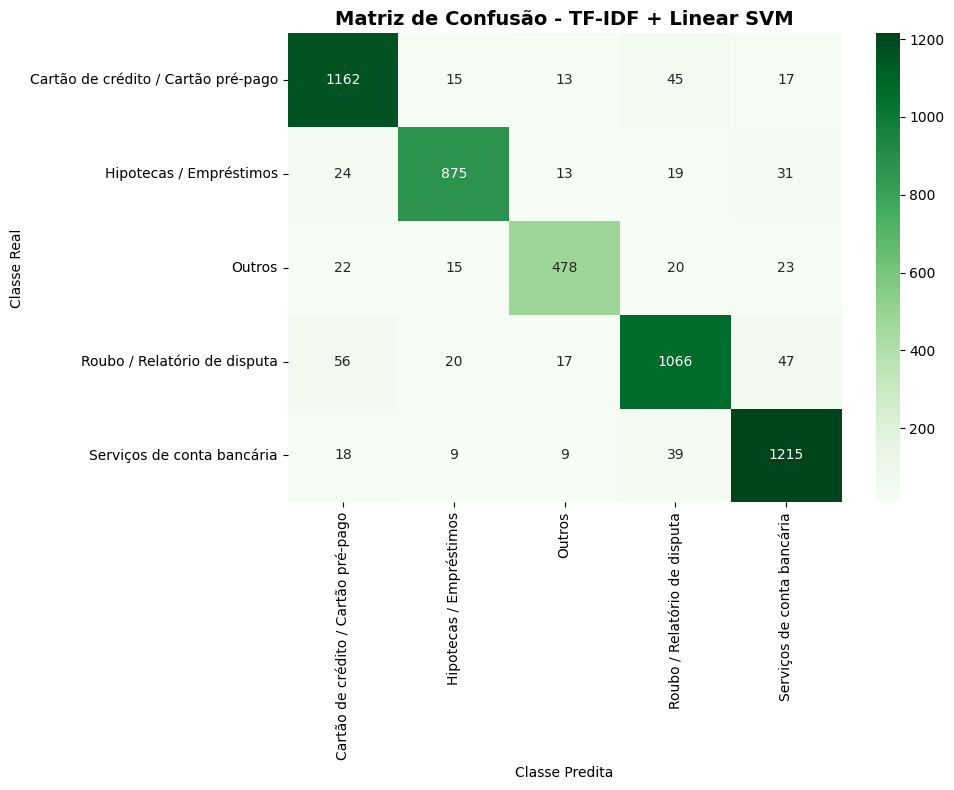

```python
# Relatório de classificação
print("\n" + "="*80)
print("RELATÓRIO DE CLASSIFICAÇÃO - EXPERIMENTO 2")
print("="*80)
print(classification_report(y_test, y_pred_svm))

# Matriz de confusão
fig, ax = plt.subplots(figsize=(10, 8))
cm = confusion_matrix(y_test, y_pred_svm)
sns.heatmap(cm, annot=True, fmt='d', cmap='Greens',
            xticklabels=grid_search_svm.classes_,
            yticklabels=grid_search_svm.classes_,
            ax=ax)
ax.set_title('Matriz de Confusão - TF-IDF + Linear SVM', fontsize=14, fontweight='bold')
ax.set_ylabel('Classe Real')
ax.set_xlabel('Classe Predita')
plt.tight_layout()
plt.show()
```

### **Experimento 3: Sentence Embedding (Transformer) + Regressão Logística**

**Justificativa da Vetorização:**

- **Sentence Embeddings**: extrai vetor denso representando semântica completa da frase
- Utiliza **Transformer multilíngue** (modelo leve pré-treinado)
- **Sem fine-tuning**: apenas extração de features, conforme visto em aula
- Captura sinonímia e contexto semântico que TF-IDF não consegue

**Modelo:** Mantemos Regressão Logística pela simplicidade e boa performance com embeddings densos.

```python
from sentence_transformers import SentenceTransformer


print("="*80)
print("EXPERIMENTO 3: SENTENCE EMBEDDING + REGRESSÃO LOGÍSTICA")
print("="*80)

# Carregar modelo de Sentence Transformer
print("\n[1/5] Carregando modelo de embeddings...")
print("  Modelo: paraphrase-multilingual-MiniLM-L12-v2")
embedding_model = SentenceTransformer('paraphrase-multilingual-MiniLM-L12-v2')
print("✓ Modelo carregado com sucesso!")

# Gerar embeddings (usando textos originais, não pré-processados)
# Transformers já lidam bem com o texto bruto
print("\n[2/5] Gerando embeddings para conjunto de treino...")
start_emb = time.time()
X_train_embeddings = embedding_model.encode(X_train.tolist(), show_progress_bar=True)
print(f"✓ Embeddings de treino gerados em {time.time() - start_emb:.2f}s")
print(f"  Shape: {X_train_embeddings.shape}")

print("\n[3/5] Gerando embeddings para conjunto de teste...")
X_test_embeddings = embedding_model.encode(X_test.tolist(), show_progress_bar=True)
print(f"✓ Embeddings de teste gerados")
print(f"  Shape: {X_test_embeddings.shape}")
```

```
WARNING:tensorflow:From c:\Users\eduhs\anaconda3\envs\dl\lib\site-packages\tf_keras\src\losses.py:2976: The name tf.losses.sparse_softmax_cross_entropy is deprecated. Please use tf.compat.v1.losses.sparse_softmax_cross_entropy instead.

================================================================================
EXPERIMENTO 3: SENTENCE EMBEDDING + REGRESSÃO LOGÍSTICA
================================================================================

[1/5] Carregando modelo de embeddings...
  Modelo: paraphrase-multilingual-MiniLM-L12-v2
```

[output not shown]

[output not shown]

[output not shown]

```
✓ Modelo carregado com sucesso!

[2/5] Gerando embeddings para conjunto de treino...
```

```
✓ Embeddings de treino gerados em 745.57s
  Shape: (15804, 384)

[3/5] Gerando embeddings para conjunto de teste...
```

```
✓ Embeddings de teste gerados
  Shape: (5268, 384)
```

```python
# Treinar Regressão Logística com GridSearch
print("\n[4/5] Treinando Regressão Logística com embeddings...")

param_grid_emb = {
    'C': [0.5, 1, 2, 4],
    'max_iter': [1000]
}

lr_emb = LogisticRegression(random_state=42)
grid_search_emb = GridSearchCV(
    lr_emb,
    param_grid_emb,
    cv=cv,
    scoring='f1_weighted',
    n_jobs=-1,
    verbose=1
)

start_time = time.time()
grid_search_emb.fit(X_train_embeddings, y_train)
train_time_emb = time.time() - start_time

print(f"✓ Treinamento concluído em {train_time_emb:.2f} segundos")

# Melhores hiperparâmetros
print("\nMelhores hiperparâmetros:")
for param, value in grid_search_emb.best_params_.items():
    print(f"  - {param}: {value}")

# Avaliação no conjunto de teste
print("\n[5/5] Avaliação no conjunto de teste...")
y_pred_emb = grid_search_emb.predict(X_test_embeddings)
f1_test_emb = f1_score(y_test, y_pred_emb, average='weighted')
accuracy_test_emb = accuracy_score(y_test, y_pred_emb)

print(f"\nResultados no Teste:")
print(f"  - F1-Score (weighted): {f1_test_emb:.4f}")
print(f"  - Accuracy: {accuracy_test_emb:.4f}")
print(f"  - Tempo de treinamento: {train_time_emb:.2f}s")

# Armazenar resultados
results_exp3 = {
    'model': 'Sentence Embedding + Regressão Logística',
    'best_params': grid_search_emb.best_params_,
    'f1_cv': grid_search_emb.best_score_,
    'f1_test': f1_test_emb,
    'accuracy_test': accuracy_test_emb,
    'train_time': train_time_emb,
    'grid_search': grid_search_emb,
    'embedding_model': embedding_model
}
```

```
[4/5] Treinando Regressão Logística com embeddings...
Fitting 5 folds for each of 4 candidates, totalling 20 fits
✓ Treinamento concluído em 46.87 segundos

Melhores hiperparâmetros:
  - C: 2
  - max_iter: 1000

[5/5] Avaliação no conjunto de teste...

Resultados no Teste:
  - F1-Score (weighted): 0.7746
  - Accuracy: 0.7752
  - Tempo de treinamento: 46.87s
```

```
================================================================================
RELATÓRIO DE CLASSIFICAÇÃO - EXPERIMENTO 3
================================================================================
                                     precision    recall  f1-score   support

Cartão de crédito / Cartão pré-pago       0.79      0.79      0.79      1252
            Hipotecas / Empréstimos       0.81      0.82      0.81       962
                             Outros       0.70      0.63      0.66       558
       Roubo / Relatório de disputa       0.73      0.73      0.73      1206
         Serviços de conta bancária       0.81      0.82      0.82      1290

                           accuracy                           0.78      5268
                          macro avg       0.77      0.76      0.76      5268
                       weighted avg       0.77      0.78      0.77      5268
```

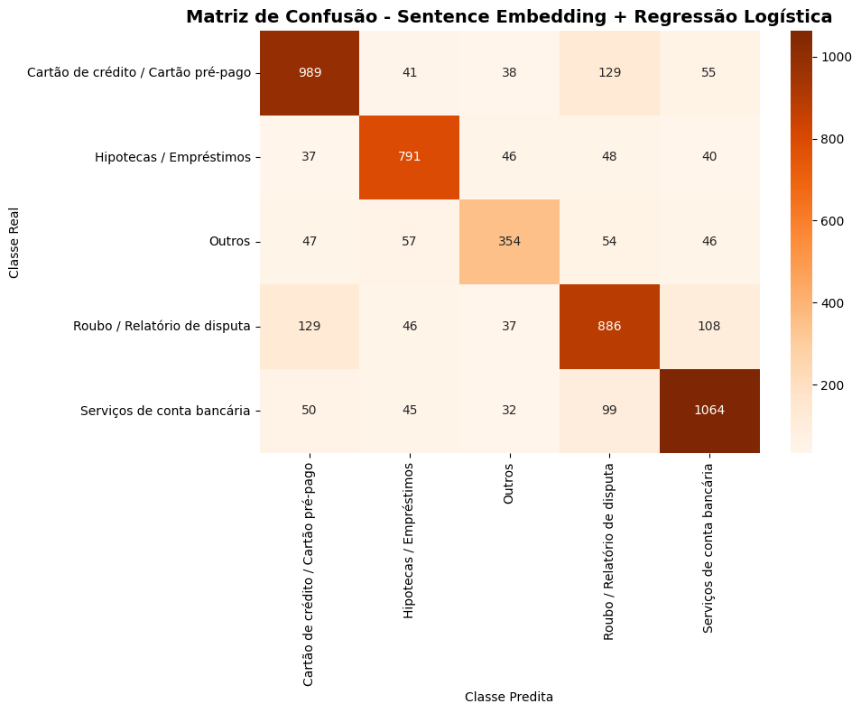

```python
# Relatório de classificação
print("\n" + "="*80)
print("RELATÓRIO DE CLASSIFICAÇÃO - EXPERIMENTO 3")
print("="*80)
print(classification_report(y_test, y_pred_emb))

# Matriz de confusão
fig, ax = plt.subplots(figsize=(10, 8))
cm = confusion_matrix(y_test, y_pred_emb)
sns.heatmap(cm, annot=True, fmt='d', cmap='Oranges',
            xticklabels=grid_search_emb.classes_,
            yticklabels=grid_search_emb.classes_,
            ax=ax)
ax.set_title('Matriz de Confusão - Sentence Embedding + Regressão Logística', fontsize=14, fontweight='bold')
ax.set_ylabel('Classe Real')
ax.set_xlabel('Classe Predita')
plt.tight_layout()
plt.show()
```

## Comparação dos Modelos e Seleção do Campeão

Uso de 5-fold CV no treino garante robustez antes do teste final.

**Critério de seleção:**

- Melhor F1-Score (weighted) no teste ≥ 0.75
- Em caso de empate: escolher modelo mais simples e leve (produção)

```python
print("="*80)
print("COMPARAÇÃO DOS MODELOS")
print("="*80)

# Consolidar resultados em DataFrame
comparacao = pd.DataFrame([
    {
        'Modelo': results_exp1['model'],
        'F1-Score CV (média)': f"{results_exp1['f1_cv']:.4f}",
        'F1-Score Teste': f"{results_exp1['f1_test']:.4f}",
        'Accuracy Teste': f"{results_exp1['accuracy_test']:.4f}",
        'Tempo Treino (s)': f"{results_exp1['train_time']:.2f}"
    },
    {
        'Modelo': results_exp2['model'],
        'F1-Score CV (média)': f"{results_exp2['f1_cv']:.4f}",
        'F1-Score Teste': f"{results_exp2['f1_test']:.4f}",
        'Accuracy Teste': f"{results_exp2['accuracy_test']:.4f}",
        'Tempo Treino (s)': f"{results_exp2['train_time']:.2f}"
    },
    {
        'Modelo': results_exp3['model'],
        'F1-Score CV (média)': f"{results_exp3['f1_cv']:.4f}",
        'F1-Score Teste': f"{results_exp3['f1_test']:.4f}",
        'Accuracy Teste': f"{results_exp3['accuracy_test']:.4f}",
        'Tempo Treino (s)': f"{results_exp3['train_time']:.2f}"
    }
])

print("\n", comparacao.to_string(index=False))

# Determinar o campeão
f1_scores = [results_exp1['f1_test'], results_exp2['f1_test'], results_exp3['f1_test']]
best_idx = np.argmax(f1_scores)
experiments = [results_exp1, results_exp2, results_exp3]
champion = experiments[best_idx]

print("\n" + "="*80)
print("🏆 MODELO CAMPEÃO")
print("="*80)
print(f"\nModelo: {champion['model']}")
print(f"F1-Score (Teste): {champion['f1_test']:.4f}")
print(f"Accuracy (Teste): {champion['accuracy_test']:.4f}")
print(f"F1-Score (CV): {champion['f1_cv']:.4f}")

if champion['f1_test'] >= 0.75:
    print(f"\n✓ Meta atingida! F1-Score > 0.75")
else:
    print(f"\n⚠ Meta não atingida. F1-Score < 0.75")
```

```
================================================================================
COMPARAÇÃO DOS MODELOS
================================================================================

                                   Modelo F1-Score CV (média) F1-Score Teste Accuracy Teste Tempo Treino (s)
            TF-IDF + Regressão Logística              0.9097         0.9132         0.9134           994.20
                     TF-IDF + Linear SVM              0.9065         0.9102         0.9104           897.37
Sentence Embedding + Regressão Logística              0.7731         0.7746         0.7752            46.87

================================================================================
🏆 MODELO CAMPEÃO
================================================================================

Modelo: TF-IDF + Regressão Logística
F1-Score (Teste): 0.9132
Accuracy (Teste): 0.9134
F1-Score (CV): 0.9097

✓ Meta atingida! F1-Score > 0.75
```

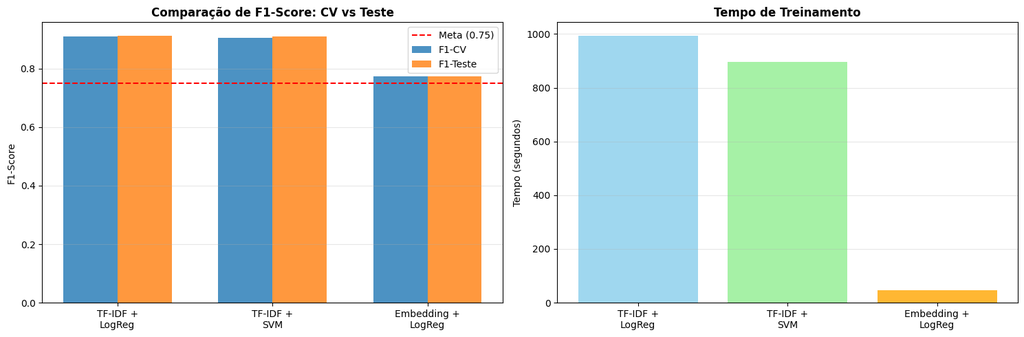

```python
# Visualização comparativa
fig, axes = plt.subplots(1, 2, figsize=(15, 5))

# F1-Score Teste
modelos = ['TF-IDF +\nLogReg', 'TF-IDF +\nSVM', 'Embedding +\nLogReg']
f1_cv_scores = [results_exp1['f1_cv'], results_exp2['f1_cv'], results_exp3['f1_cv']]
f1_test_scores = [results_exp1['f1_test'], results_exp2['f1_test'], results_exp3['f1_test']]

x_pos = np.arange(len(modelos))
width = 0.35

axes[0].bar(x_pos - width/2, f1_cv_scores, width, label='F1-CV', alpha=0.8)
axes[0].bar(x_pos + width/2, f1_test_scores, width, label='F1-Teste', alpha=0.8)
axes[0].axhline(y=0.75, color='r', linestyle='--', label='Meta (0.75)')
axes[0].set_ylabel('F1-Score')
axes[0].set_title('Comparação de F1-Score: CV vs Teste', fontweight='bold')
axes[0].set_xticks(x_pos)
axes[0].set_xticklabels(modelos)
axes[0].legend()
axes[0].grid(axis='y', alpha=0.3)

# Tempo de Treinamento
tempos = [results_exp1['train_time'], results_exp2['train_time'], results_exp3['train_time']]
axes[1].bar(modelos, tempos, color=['skyblue', 'lightgreen', 'orange'], alpha=0.8)
axes[1].set_ylabel('Tempo (segundos)')
axes[1].set_title('Tempo de Treinamento', fontweight='bold')
axes[1].grid(axis='y', alpha=0.3)

plt.tight_layout()
plt.show()
```

### **Validação do professor**

Consolidar apenas os scripts do seu **modelo campeão**, desde o carregamento do dataframe, separação das amostras, tratamentos utilizados (funções, limpezas, etc.), criação dos objetos de vetorização dos textos e modelo treinado e outras implementações utilizadas no processo de desenvolvimento do modelo.

O modelo precisar atingir um score na métrica F1 Score superior a 75%.

**Atenção:**

- **Implemente aqui apenas os scripts que fazem parte do modelo campeão.**
- **Execute o pipeline do modelo campeão completamente para garantir que não tetá erros no script.**

```python
# 1. BÁSICOS
import pandas as pd
import numpy as np
import matplotlib.pyplot as plt
import seaborn as sns
import re
import time
import warnings
warnings.filterwarnings('ignore')

# 2. NLP
import nltk
from nltk.corpus import stopwords
from nltk.stem import RSLPStemmer
import spacy

# 3. SKLEARN - MODELOS E MÉTRICAS
from sklearn.model_selection import train_test_split, GridSearchCV, StratifiedKFold
from sklearn.feature_extraction.text import TfidfVectorizer, CountVectorizer
from sklearn.linear_model import LogisticRegression
from sklearn.svm import LinearSVC
from sklearn.metrics import (
    accuracy_score, f1_score, classification_report,
    confusion_matrix, precision_score, recall_score
)

# 4. PIPELINE
from sklearn.pipeline import Pipeline
from sklearn.base import BaseEstimator, TransformerMixin


# 6. DOWNLOADS NLTK
nltk.download('stopwords', quiet=True)
nltk.download('rslp', quiet=True)
nltk.download('punkt', quiet=True)

# 7. SPAcy
try:
    nlp = spacy.load('pt_core_news_sm', disable=["parser", "ner"])
    nlp.max_length = 2_000_000
    print("✓ Modelo spaCy otimizado carregado!")
except:
    print("⚠ Modelo spaCy não encontrado. Execute: python -m spacy download pt_core_news_sm")
    nlp = None
```

```
✓ Modelo spaCy otimizado carregado!
```

```python
df = pd.read_csv('tickets_reclamacoes_classificados.csv', delimiter = ';')
```

```python
# Stopwords customizadas
custom_stopwords = [
    'cliente', 'favor', 'gostaria', 'solicito', 'peço', 'preciso',
    'reclamação', 'reclamações', 'problema', 'problemas',
    'situação', 'situações', 'caso', 'casos',
    'informação', 'informações', 'dados', 'dado',
    'atendimento', 'atendimentos', 'contato', 'contatos',
    'serviço', 'serviços'
]

# Adicionar stopwords em inglês leve
stopwords_en_light = ['the', 'and', 'or', 'but', 'in', 'on', 'at', 'to', 'for', 'of', 'with', 'by']

# Combinar todas as stopwords em uma LISTA
stop_words_pt = list(stopwords.words('portuguese')) + custom_stopwords + stopwords_en_light

# Converter para lista única (remover duplicatas)
stop_words_pt = list(set(stop_words_pt))
```

```python
def clean_text(text):
    """
    Remove tokens mascarados específicos do domínio financeiro

    Parâmetros:
    - text: texto a ser limpo

    Retorna:
    - texto limpo sem tokens mascarados
    """
    if not isinstance(text, str):
        return ""

    # Converter para lowercase
    text = text.lower()

    # Remover tokens mascarados
    text = re.sub(r'\b[xX]{2,}\b', '', text)  # Remove xxxx, xx
    text = re.sub(r'\b\d{2,}\b', '', text)     # Remove 00, 2020, etc.

    # Limpar espaços extras
    text = re.sub(r'\s+', ' ', text).strip()

    return text

# IMPLEMENTAÇÃO: Lematização otimizada para performance
import spacy

# 1) Carregar spaCy otimizado
try:
    nlp = spacy.load("pt_core_news_sm", disable=["parser", "ner"])  # só POS + lemmatização
    nlp.max_length = 2_000_000  # folga para textos maiores
    print("✓ Modelo spaCy otimizado carregado!")
except:
    print("⚠ Modelo spaCy não encontrado. Execute: python -m spacy download pt_core_news_sm")
    nlp = None

# 2) Lematização em lote otimizada
def lemmatize_text_batch(texts, keep_pos=("NOUN", "VERB", "ADJ"), batch_size=300, n_process=-1):
    """
    Lematização otimizada para grandes volumes de texto
    """
    if nlp is None:
        return texts

    sw = stop_words_pt if isinstance(stop_words_pt, set) else set(stop_words_pt)
    single = isinstance(texts, str)
    if single:
        texts = [texts]

    out = []
    with nlp.select_pipes(disable=[]):  # já desativamos parser/ner no load
        for doc in nlp.pipe(texts, batch_size=batch_size, n_process=n_process):
            lemmas = [
                t.lemma_ for t in doc
                if t.pos_ in keep_pos and len(t.lemma_) > 2 and t.lemma_ not in sw
            ]
            out.append(" ".join(lemmas))

    return out[0] if single else out

# 3) Pré-processador vetorizado
def preprocess_text_series(texts, use_lemmatization=True):
    """
    Pré-processamento otimizado para Series do pandas
    """
    texts = texts.fillna("").astype(str)
    texts = texts.map(clean_text)

    if not use_lemmatization:
        sw = stop_words_pt if isinstance(stop_words_pt, set) else set(stop_words_pt)
        return texts.map(lambda t: " ".join(w for w in t.split() if len(w) > 2 and w not in sw))

    return pd.Series(lemmatize_text_batch(texts, batch_size=300, n_process=-1), index=texts.index)
```

```
✓ Modelo spaCy otimizado carregado!
```

```python
from sklearn.model_selection import train_test_split


X = df['descricao_reclamacao']
y = df['categoria']

X_train, X_test, y_train, y_test = train_test_split(
    X, y,
    test_size=0.25,
    random_state=42,
    stratify=y
)

print(f"Conjunto de Treino: {len(X_train)} amostras ({len(X_train)/len(X)*100:.1f}%)")
print(f"Conjunto de Teste: {len(X_test)} amostras ({len(X_test)/len(X)*100:.1f}%)")
print(f"\nDistribuição de classes no treino:")
print(y_train.value_counts())
```

```
Conjunto de Treino: 15804 amostras (75.0%)
Conjunto de Teste: 5268 amostras (25.0%)

Distribuição de classes no treino:
categoria
Serviços de conta bancária             3871
Cartão de crédito / Cartão pré-pago    3754
Roubo / Relatório de disputa           3616
Hipotecas / Empréstimos                2888
Outros                                 1675
Name: count, dtype: int64
```

```python
import time
from sklearn.feature_extraction.text import TfidfVectorizer
from sklearn.linear_model import LogisticRegression
from sklearn.metrics import accuracy_score, f1_score
from sklearn.model_selection import GridSearchCV, StratifiedKFold
from sklearn.pipeline import Pipeline


print("="*80)
print("EXPERIMENTO 1: TF-IDF + REGRESSÃO LOGÍSTICA")
print("="*80)

# Pré-processar os textos (aplicar lematização)
print("\n[1/5] Pré-processando textos...")
X_train_processed = preprocess_text_series(X_train, use_lemmatization=True)
X_test_processed = preprocess_text_series(X_test, use_lemmatization=True)
print(f"✓ Processados {len(X_train_processed)} textos de treino e {len(X_test_processed)} de teste")

# Definir o pipeline
print("\n[2/5] Configurando pipeline e Grid Search...")
pipeline_lr = Pipeline([
    ('tfidf', TfidfVectorizer()),
    ('clf', LogisticRegression(max_iter=1000, random_state=42))
])

# Grid de hiperparâmetros
param_grid_lr = {
    'tfidf__ngram_range': [(1, 1), (1, 2)],
    'tfidf__sublinear_tf': [True, False],
    'tfidf__min_df': [1, 2, 3],
    'clf__C': [0.5, 1, 2, 4]
}

# GridSearchCV com 5-fold estratificado
cv = StratifiedKFold(n_splits=5, shuffle=True, random_state=42)

grid_search_lr = GridSearchCV(
    pipeline_lr,
    param_grid_lr,
    cv=cv,
    scoring='f1_weighted',
    n_jobs=-1,
    verbose=1
)

# Treinamento
print("\n[3/5] Treinando modelo com GridSearchCV (5-fold)...")
start_time = time.time()
grid_search_lr.fit(X_train_processed, y_train)
train_time = time.time() - start_time

print(f"✓ Treinamento concluído em {train_time:.2f} segundos")

# Melhores hiperparâmetros
print("\n[4/5] Melhores hiperparâmetros encontrados:")
for param, value in grid_search_lr.best_params_.items():
    print(f"  - {param}: {value}")

# Avaliação no conjunto de teste
print("\n[5/5] Avaliação no conjunto de teste...")
y_pred_lr = grid_search_lr.predict(X_test_processed)
f1_test_lr = f1_score(y_test, y_pred_lr, average='weighted')
accuracy_test_lr = accuracy_score(y_test, y_pred_lr)

print(f"\nResultados no Teste:")
print(f"  - F1-Score (weighted): {f1_test_lr:.4f}")
print(f"  - Accuracy: {accuracy_test_lr:.4f}")
print(f"  - Tempo de treinamento: {train_time:.2f}s")

# Armazenar resultados
results_exp1 = {
    'model': 'TF-IDF + Regressão Logística',
    'best_params': grid_search_lr.best_params_,
    'f1_cv': grid_search_lr.best_score_,
    'f1_test': f1_test_lr,
    'accuracy_test': accuracy_test_lr,
    'train_time': train_time,
    'grid_search': grid_search_lr
}
```

```
================================================================================
EXPERIMENTO 1: TF-IDF + REGRESSÃO LOGÍSTICA
================================================================================

[1/5] Pré-processando textos...
✓ Processados 15804 textos de treino e 5268 de teste

[2/5] Configurando pipeline e Grid Search...

[3/5] Treinando modelo com GridSearchCV (5-fold)...
Fitting 5 folds for each of 48 candidates, totalling 240 fits
✓ Treinamento concluído em 1481.98 segundos

[4/5] Melhores hiperparâmetros encontrados:
  - clf__C: 4
  - tfidf__min_df: 3
  - tfidf__ngram_range: (1, 2)
  - tfidf__sublinear_tf: False

[5/5] Avaliação no conjunto de teste...

Resultados no Teste:
  - F1-Score (weighted): 0.9128
  - Accuracy: 0.9131
  - Tempo de treinamento: 1481.98s
```

```
================================================================================
RELATÓRIO DE CLASSIFICAÇÃO - EXPERIMENTO 1
================================================================================
                                     precision    recall  f1-score   support

Cartão de crédito / Cartão pré-pago       0.91      0.93      0.92      1252
            Hipotecas / Empréstimos       0.92      0.92      0.92       962
                             Outros       0.91      0.84      0.87       558
       Roubo / Relatório de disputa       0.90      0.89      0.90      1206
         Serviços de conta bancária       0.92      0.94      0.93      1290

                           accuracy                           0.91      5268
                          macro avg       0.91      0.90      0.91      5268
                       weighted avg       0.91      0.91      0.91      5268
```

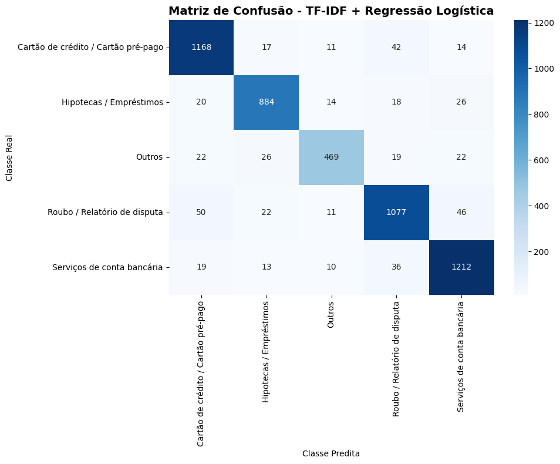

```python
print("\n" + "="*80)
print("RELATÓRIO DE CLASSIFICAÇÃO - EXPERIMENTO 1")
print("="*80)
print(classification_report(y_test, y_pred_lr))

# Matriz de confusão
fig, ax = plt.subplots(figsize=(10, 8))
cm = confusion_matrix(y_test, y_pred_lr)
sns.heatmap(cm, annot=True, fmt='d', cmap='Blues',
            xticklabels=grid_search_lr.classes_,
            yticklabels=grid_search_lr.classes_,
            ax=ax)
ax.set_title('Matriz de Confusão - TF-IDF + Regressão Logística', fontsize=14, fontweight='bold')
ax.set_ylabel('Classe Real')
ax.set_xlabel('Classe Predita')
plt.tight_layout()
plt.show()
```

```python
print(f"\n{'='*80}")
print("EXEMPLOS DE PREDIÇÕES (10 CASOS DO CONJUNTO DE TESTE)")
print(f"{'='*80}\n")


sample_indices = np.random.choice(X_test_processed.index, size=min(10, len(X_test_processed)), replace=False)

for idx, test_idx in enumerate(sample_indices, 1):
    texto_original = X_test.loc[test_idx]
    classe_real = y_test.loc[test_idx]

    # Para TF-IDF, usar texto processado
    texto_processado = X_test_processed.loc[test_idx]
    classe_predita = grid_search_lr.predict([texto_processado])[0]

    correto = "✓" if classe_real == classe_predita else "✗"

    print(f"[{idx}] {correto}")
    print(f"  Texto: {texto_original[:100]}...")
    print(f"  Real: {classe_real}")
    print(f"  Predito: {classe_predita}")
```

```
================================================================================
EXEMPLOS DE PREDIÇÕES (10 CASOS DO CONJUNTO DE TESTE)
================================================================================

[1] ✓
  Texto: J.P. Morgan Mortgage XXXX XXXX XXXX XXXX XXXX XXXX XXXX / XXXX XXXX XXXX XXXX XXXX XXXX XXXX XXXX XX...
  Real: Hipotecas / Empréstimos
  Predito: Hipotecas / Empréstimos
[2] ✗
  Texto: O JP Morgan Chase mentiu descaradamente para a Agência de Finanças do Consumidor/Comissão Federal de...
  Real: Cartão de crédito / Cartão pré-pago
  Predito: Roubo / Relatório de disputa
[3] ✓
  Texto: Eu tinha saldos promocionais xxxx 0 % - xxxx expirado xxxx/xxxx/17 O outro expira xxxx/xxxx/17. Em x...
  Real: Outros
  Predito: Outros
[4] ✓
  Texto: Recebi uma chamada de xxxx xxxx xxxx, xxxx. Xxxx xxxx, xxxx xxxx, il xxxx.
Lá, o número de telefone...
  Real: Serviços de conta bancária
  Predito: Serviços de conta bancária
[5] ✗
  Texto: Eu sou um cliente fiel do Chase Bank desde xxxx. Em xxxx, abri uma conta de cartão de crédito com el...
  Real: Roubo / Relatório de disputa
  Predito: Cartão de crédito / Cartão pré-pago
[6] ✓
  Texto: Caro CFPB, Meu nome é xxxx xxxx xxxx xxxx de xxxx xxxx xxxx e xxxx xxxx xxxx Infelizmente ambos fale...
  Real: Hipotecas / Empréstimos
  Predito: Hipotecas / Empréstimos
[7] ✓
  Texto: No FRI XXXX XX/XX/2018, recebi um pacote XXXX noturno da XXXX XXXX, um funcionário do JP Morgan Chas...
  Real: Hipotecas / Empréstimos
  Predito: Hipotecas / Empréstimos
[8] ✓
  Texto: Estou recebendo contas não autorizadas da Chase sobre o número da conta xxxx. Aparentemente, Chase a...
  Real: Serviços de conta bancária
  Predito: Serviços de conta bancária
[9] ✓
  Texto: Fui ao site para tentar fazer um pagamento na minha conta e ele foi fechado. O Chase Bank disse que ...
  Real: Outros
  Predito: Outros
[10] ✓
  Texto: Verificamos nosso saldo em xx/xx/xxxx e ele tinha {$ 240,00} na conta, fizemos algumas transações de...
  Real: Outros
  Predito: Outros
```